# Phyloseq PreProcessing

Calla Bush

2024-03-20

# Load libraries

```r
#install_github("joey711/phyloseq")

pacman::p_load(devtools, phyloseq, tidyverse, dada2, install = FALSE)
```

# Goals

Here, we will process the data into a phyloseq object.

- ASV table
- Taxonomy table
- Track Reads (metadata)

Then, we will remove the following:

1. Remove Chloroplasts.
2. Remove Mitochondria.
3. Remove ASVs from negative controls and alos negative control samples.
4. Evaluate accuracy by looking at the Mock Community
5. Remove samples without “enough” reads.

# Load data

## ASV table

```r
# First, load ASV table
load("data/01_DADA2/ASV_counts.RData")

# Inspect ASV_tab
head(asv_tab)[,1:5]
```

```
##       022um-Control_R1_filtered.fastq.gz 20210602-MA-ABB1F_R1_filtered.fastq.gz
## ASV_1                                  0                                    594
## ASV_2                                  0                                    246
## ASV_3                               7707                                     46
## ASV_4                                  0                                    379
## ASV_5                                  0                                    130
## ASV_6                                  0                                    164
##       20210602-MA-ABB1P_R1_filtered.fastq.gz
## ASV_1                                    416
## ASV_2                                    176
## ASV_3                                      0
## ASV_4                                    315
## ASV_5                                    103
## ASV_6                                    164
##       20210602-MA-ABB1W_R1_filtered.fastq.gz
## ASV_1                                    876
## ASV_2                                    296
## ASV_3                                      0
## ASV_4                                    592
## ASV_5                                    188
## ASV_6                                    214
##       20210602-MA-ABS1F_R1_filtered.fastq.gz
## ASV_1                                    495
## ASV_2                                    206
## ASV_3                                      0
## ASV_4                                    393
## ASV_5                                    133
## ASV_6                                    112
```

```r
# Fix names
sample_names <- colnames(asv_tab)
samples_fixed <- sapply(strsplit(basename(sample_names), "_"), `[`,1)
head(samples_fixed)
```

```
## [1] "022um-Control"     "20210602-MA-ABB1F" "20210602-MA-ABB1P"
## [4] "20210602-MA-ABB1W" "20210602-MA-ABS1F" "20210602-MA-ABS1P"
```

```r
# re-write the ASV count file to fix names
colnames(asv_tab) <- samples_fixed
str(asv_tab)
```

```
##  int [1:3080, 1:95] 0 0 7707 0 0 0 0 0 0 0 ...
##  - attr(*, "dimnames")=List of 2
##   ..$ : chr [1:3080] "ASV_1" "ASV_2" "ASV_3" "ASV_4" ...
##   ..$ : chr [1:95] "022um-Control" "20210602-MA-ABB1F" "20210602-MA-ABB1P" "20210602-MA-ABB1W" ...
```

## Taxonomy table

```r
tax_df <- read.table("data/01_DADA2/ASV_taxonomy.tsv", sep = "\t", skip = 1)
head(tax_df)
```

```
##      V1       V2               V3                  V4              V5
## 1 ASV_1 Bacteria    Cyanobacteria      Cyanobacteriia Synechococcales
## 2 ASV_2 Bacteria    Cyanobacteria      Cyanobacteriia Synechococcales
## 3 ASV_3 Bacteria   Proteobacteria Gammaproteobacteria Pseudomonadales
## 4 ASV_4 Bacteria Actinobacteriota      Acidimicrobiia Actinomarinales
## 5 ASV_5 Bacteria Actinobacteriota      Acidimicrobiia Actinomarinales
## 6 ASV_6 Bacteria   Proteobacteria Gammaproteobacteria Pseudomonadales
##                 V6                      V7   V8    V9
## 1     Cyanobiaceae      Cyanobium PCC-6307 <NA> ASV_1
## 2     Cyanobiaceae      Cyanobium PCC-6307 <NA> ASV_2
## 3 Pseudomonadaceae             Pseudomonas <NA> ASV_3
## 4 Actinomarinaceae Candidatus Actinomarina <NA> ASV_4
## 5 Actinomarinaceae Candidatus Actinomarina <NA> ASV_5
## 6      SAR86 clade                    <NA> <NA> ASV_6
##                                                                                                                                                                                                                                                         V10
## 1 CGGGAGTGGCAAGCGTTATCCGGAATTATTGGGCGTAAAGCGTCCGCAGGCGGTCTGTCA…
## 2 CGGGAGTGGCAAGCGTTATCCGGAATTATTGGGCGTAAAGCGTCCGCAGGCGGTCTTGTA…
## 3 CAGAGGGTGCAAGCGTTAATCGGAATTACTGGGCGTAAAGCGCGCGTAGGTGGTTCGTTA…
## 4  GTAGGGGGCGAGCGTTGTCCGGATTTATTGGGCGTAAAGAGCTCGTAGGCGGTTCAACAA…
## 5  GTAGGGGGCGAGCGTTGTCCGGATTTATTGGGCGTAAAGAGCTCGTAGGCGGTTCAACAA…
## 6 CGGAAGGTCCAAGCGTTAATCGGAATTACTGGGCGTAAAGCGCGCGTAGGTGGTTTATTA…
```

```r
# fix column names
colnames(tax_df) <- c("asv_names", "Kingdom", "Phylum", "Class", "Order", "Family", "Genus", "Species", "ASV", "ASVseq")

head(tax_df)
```

```
##   asv_names  Kingdom           Phylum               Class           Order
## 1     ASV_1 Bacteria    Cyanobacteria      Cyanobacteriia Synechococcales
## 2     ASV_2 Bacteria    Cyanobacteria      Cyanobacteriia Synechococcales
## 3     ASV_3 Bacteria   Proteobacteria Gammaproteobacteria Pseudomonadales
## 4     ASV_4 Bacteria Actinobacteriota      Acidimicrobiia Actinomarinales
## 5     ASV_5 Bacteria Actinobacteriota      Acidimicrobiia Actinomarinales
## 6     ASV_6 Bacteria   Proteobacteria Gammaproteobacteria Pseudomonadales
##             Family                   Genus Species   ASV
## 1     Cyanobiaceae      Cyanobium PCC-6307    <NA> ASV_1
## 2     Cyanobiaceae      Cyanobium PCC-6307    <NA> ASV_2
## 3 Pseudomonadaceae             Pseudomonas    <NA> ASV_3
## 4 Actinomarinaceae Candidatus Actinomarina    <NA> ASV_4
## 5 Actinomarinaceae Candidatus Actinomarina    <NA> ASV_5
## 6      SAR86 clade                    <NA>    <NA> ASV_6
##                                                                                                                                                                                                                                                      ASVseq
## 1 CGGGAGTGGCAAGCGTTATCCGGAATTATTGGGCGTAAAGCGTCCGCAGGCGGTCTGTCA…
## 2 CGGGAGTGGCAAGCGTTATCCGGAATTATTGGGCGTAAAGCGTCCGCAGGCGGTCTTGTA…
## 3 CAGAGGGTGCAAGCGTTAATCGGAATTACTGGGCGTAAAGCGCGCGTAGGTGGTTCGTTA…
## 4  GTAGGGGGCGAGCGTTGTCCGGATTTATTGGGCGTAAAGAGCTCGTAGGCGGTTCAACAA…
## 5  GTAGGGGGCGAGCGTTGTCCGGATTTATTGGGCGTAAAGAGCTCGTAGGCGGTTCAACAA…
## 6 CGGAAGGTCCAAGCGTTAATCGGAATTACTGGGCGTAAAGCGCGCGTAGGTGGTTTATTA…
```

```r
#Taxonomy Table Matrix
tax_mat <-
tax_df %>%
  tibble::column_to_rownames(., var = "asv_names") %>%
  as.matrix()
```

## Track Reads Data

```r
load("data/01_DADA2/track_read_counts.RData")

# Take a look at the data
track_counts_df
```

```
##                names input filtered denoisedF denoisedR merged nochim
## 1      022um-Control  8722     8023      8009      7975   7972   7972
## 2  20210602-MA-ABB1F  5156     4632      4411      4366   4166   4143
## 3  20210602-MA-ABB1P  5051     4597      4046      4010   3702   3657
## 4  20210602-MA-ABB1W  7695     7023      6460      6424   6087   5999
## 5  20210602-MA-ABS1F  5098     4595      4208      4180   3922   3874
## 6  20210602-MA-ABS1P  5900     5314      4646      4663   4335   4324
## 7  20210602-MA-ABS1W  6786     6145      5627      5629   5236   5121
## 8  20210602-MA-CEB1F  6081     5489      5095      5056   4816   4789
## 9  20210602-MA-CEB1P  7594     6954      6470      6464   6088   5517
## 10 20210602-MA-CEB1W  7307     6599      6054      6097   5828   5736
## 11 20210602-MA-CES1F  6778     5869      5484      5504   5181   5022
## 12 20210602-MA-CES1P  6117     5632      5182      5151   4875   4713
## 13 20210602-MA-CES1W  5764     5157      4776      4792   4494   4422
## 14 20210602-MA-CWB1F  4122     3708      3268      3237   3003   2980
```

[output cut: 177 more lines]

```r
# Make sure all data in ASV table matches ASV taxonomy
head(track_counts_df)
```

```
##               names input filtered denoisedF denoisedR merged nochim
## 1     022um-Control  8722     8023      8009      7975   7972   7972
## 2 20210602-MA-ABB1F  5156     4632      4411      4366   4166   4143
## 3 20210602-MA-ABB1P  5051     4597      4046      4010   3702   3657
## 4 20210602-MA-ABB1W  7695     7023      6460      6424   6087   5999
## 5 20210602-MA-ABS1F  5098     4595      4208      4180   3922   3874
## 6 20210602-MA-ABS1P  5900     5314      4646      4663   4335   4324
##   perc_reads_retained
## 1            91.40105
## 2            80.35299
## 3            72.40150
## 4            77.95971
## 5            75.99058
## 6            73.28814
```

```r
dim(track_counts_df)
```

```
## [1] 95  8
```

```r
# Please in the terminal copy metadata.csv to data folder
# into: /workdir/cab565/git_repos/SalinityGradient_16S/data
# from: /workdir/in_class_data/SalinityGradient_16S/metadata.csv

#Load in metadata
metadata_df <- read.csv("data/metadata.csv")
head(metadata_df)
```

```
##   X             names year day project     station depth replicate fraction
## 1 1     022um-Control 022u  Co      tr     Control   0.0        NA  Control
## 2 2 20210602-MA-ABB1F 2021  02      MA Aransas Bay   2.5         1     Free
## 3 3 20210602-MA-ABB1P 2021  02      MA Aransas Bay   2.5         1 Particle
## 4 4 20210602-MA-ABB1W 2021  02      MA Aransas Bay   2.5         1    Whole
## 5 5 20210602-MA-ABS1F 2021  02      MA Aransas Bay   0.0         1     Free
## 6 6 20210602-MA-ABS1P 2021  02      MA Aransas Bay   0.0         1 Particle
##     date month vol_filtered_mL DNA_conc1a_nguL total_uL_DNA tot_ng
## 1   <NA>  <NA>              NA           0.001           NA     NA
## 2 6/2/21  June             360          25.900        44.61   1207
## 3 6/2/21  June             360           2.910        34.00    105
## 4 6/2/21  June             360          65.300        43.36   2962
## 5 6/2/21  June             300          39.700        44.94   1864
## 6 6/2/21  June             300          10.400        42.54    463
##   DNA_conc1b_nguL  DNA_conc2_nguL tot_filtration_time collection_time
```

[output cut: 34 more lines]

```r
dim(metadata_df)
```

```
## [1] 95 41
```

```r
# Merge metadata df with track_reads_df
head(metadata_df)
```

```
##   X             names year day project     station depth replicate fraction
## 1 1     022um-Control 022u  Co      tr     Control   0.0        NA  Control
## 2 2 20210602-MA-ABB1F 2021  02      MA Aransas Bay   2.5         1     Free
## 3 3 20210602-MA-ABB1P 2021  02      MA Aransas Bay   2.5         1 Particle
## 4 4 20210602-MA-ABB1W 2021  02      MA Aransas Bay   2.5         1    Whole
## 5 5 20210602-MA-ABS1F 2021  02      MA Aransas Bay   0.0         1     Free
## 6 6 20210602-MA-ABS1P 2021  02      MA Aransas Bay   0.0         1 Particle
##     date month vol_filtered_mL DNA_conc1a_nguL total_uL_DNA tot_ng
## 1   <NA>  <NA>              NA           0.001           NA     NA
## 2 6/2/21  June             360          25.900        44.61   1207
## 3 6/2/21  June             360           2.910        34.00    105
## 4 6/2/21  June             360          65.300        43.36   2962
## 5 6/2/21  June             300          39.700        44.94   1864
## 6 6/2/21  June             300          10.400        42.54    463
##   DNA_conc1b_nguL  DNA_conc2_nguL tot_filtration_time collection_time
```

[output cut: 34 more lines]

```r
head(track_counts_df)
```

```
##               names input filtered denoisedF denoisedR merged nochim
## 1     022um-Control  8722     8023      8009      7975   7972   7972
## 2 20210602-MA-ABB1F  5156     4632      4411      4366   4166   4143
## 3 20210602-MA-ABB1P  5051     4597      4046      4010   3702   3657
## 4 20210602-MA-ABB1W  7695     7023      6460      6424   6087   5999
## 5 20210602-MA-ABS1F  5098     4595      4208      4180   3922   3874
## 6 20210602-MA-ABS1P  5900     5314      4646      4663   4335   4324
##   perc_reads_retained
## 1            91.40105
## 2            80.35299
## 3            72.40150
## 4            77.95971
## 5            75.99058
## 6            73.28814
```

```r
metadata_track_reads_df <-
  metadata_df %>%
  left_join(., track_counts_df, by = "names") %>%
  dplyr::select(-X)

head(metadata_track_reads_df)
```

```
##               names year day project     station depth replicate fraction
## 1     022um-Control 022u  Co      tr     Control   0.0        NA  Control
## 2 20210602-MA-ABB1F 2021  02      MA Aransas Bay   2.5         1     Free
## 3 20210602-MA-ABB1P 2021  02      MA Aransas Bay   2.5         1 Particle
## 4 20210602-MA-ABB1W 2021  02      MA Aransas Bay   2.5         1    Whole
## 5 20210602-MA-ABS1F 2021  02      MA Aransas Bay   0.0         1     Free
## 6 20210602-MA-ABS1P 2021  02      MA Aransas Bay   0.0         1 Particle
##     date month vol_filtered_mL DNA_conc1a_nguL total_uL_DNA tot_ng
## 1   <NA>  <NA>              NA           0.001           NA     NA
## 2 6/2/21  June             360          25.900        44.61   1207
## 3 6/2/21  June             360           2.910        34.00    105
## 4 6/2/21  June             360          65.300        43.36   2962
## 5 6/2/21  June             300          39.700        44.94   1864
## 6 6/2/21  June             300          10.400        42.54    463
##   DNA_conc1b_nguL  DNA_conc2_nguL tot_filtration_time collection_time
```

[output cut: 41 more lines]

```r
# Update row.names to be sample names
## Before
row.names(metadata_track_reads_df)
```

```
##  [1] "1"  "2"  "3"  "4"  "5"  "6"  "7"  "8"  "9"  "10" "11" "12" "13" "14" "15"
## [16] "16" "17" "18" "19" "20" "21" "22" "23" "24" "25" "26" "27" "28" "29" "30"
## [31] "31" "32" "33" "34" "35" "36" "37" "38" "39" "40" "41" "42" "43" "44" "45"
## [46] "46" "47" "48" "49" "50" "51" "52" "53" "54" "55" "56" "57" "58" "59" "60"
## [61] "61" "62" "63" "64" "65" "66" "67" "68" "69" "70" "71" "72" "73" "74" "75"
## [76] "76" "77" "78" "79" "80" "81" "82" "83" "84" "85" "86" "87" "88" "89" "90"
## [91] "91" "92" "93" "94" "95"
```

```r
## Rewrite
row.names(metadata_track_reads_df) <- metadata_track_reads_df$names
## Check that it worked
row.names(metadata_track_reads_df)
```

```
##  [1] "022um-Control"     "20210602-MA-ABB1F" "20210602-MA-ABB1P"
##  [4] "20210602-MA-ABB1W" "20210602-MA-ABS1F" "20210602-MA-ABS1P"
##  [7] "20210602-MA-ABS1W" "20210602-MA-CEB1F" "20210602-MA-CEB1P"
## [10] "20210602-MA-CEB1W" "20210602-MA-CES1F" "20210602-MA-CES1P"
## [13] "20210602-MA-CES1W" "20210602-MA-CWB1F" "20210602-MA-CWB1P"
## [16] "20210602-MA-CWB1W" "20210602-MA-CWS1F" "20210602-MA-CWS1P"
## [19] "20210602-MA-CWS1W" "20210602-MA-MBB1F" "20210602-MA-MBB1P"
## [22] "20210602-MA-MBB1W" "20210602-MA-MBS1F" "20210602-MA-MBS1P"
## [25] "20210602-MA-MBS1W" "20210602-MA-SCB1F" "20210602-MA-SCB1P"
## [28] "20210602-MA-SCB1W" "20210602-MA-SCS1F" "20210602-MA-SCS1P"
## [31] "20210602-MA-SCS1W" "20210615-MA-ABB2F" "20210615-MA-ABB2P"
## [34] "20210615-MA-ABB2W" "20210615-MA-ABS1F" "20210615-MA-ABS1P"
## [37] "20210615-MA-ABS1W" "20210615-MA-CEB1F" "20210615-MA-CEB1P"
## [40] "20210615-MA-CEB1W" "20210615-MA-CES1F" "20210615-MA-CES1P"
## [43] "20210615-MA-CES1W" "20210615-MA-CWB1F" "20210615-MA-CWB1P"
```

[output cut: 17 more lines]

```r
# Intuition check
head(metadata_track_reads_df)
```

```
##                               names year day project     station depth
## 022um-Control         022um-Control 022u  Co      tr     Control   0.0
## 20210602-MA-ABB1F 20210602-MA-ABB1F 2021  02      MA Aransas Bay   2.5
## 20210602-MA-ABB1P 20210602-MA-ABB1P 2021  02      MA Aransas Bay   2.5
## 20210602-MA-ABB1W 20210602-MA-ABB1W 2021  02      MA Aransas Bay   2.5
## 20210602-MA-ABS1F 20210602-MA-ABS1F 2021  02      MA Aransas Bay   0.0
## 20210602-MA-ABS1P 20210602-MA-ABS1P 2021  02      MA Aransas Bay   0.0
##                   replicate fraction   date month vol_filtered_mL
## 022um-Control            NA  Control   <NA>  <NA>              NA
## 20210602-MA-ABB1F         1     Free 6/2/21  June             360
## 20210602-MA-ABB1P         1 Particle 6/2/21  June             360
## 20210602-MA-ABB1W         1    Whole 6/2/21  June             360
## 20210602-MA-ABS1F         1     Free 6/2/21  June             300
## 20210602-MA-ABS1P         1 Particle 6/2/21  June             300
##                   DNA_conc1a_nguL total_uL_DNA tot_ng DNA_conc1b_nguL
## 022um-Control               0.001           NA     NA              NA
## 20210602-MA-ABB1F          25.900        44.61   1207              NA
## 20210602-MA-ABB1P           2.910        34.00    105              NA
## 20210602-MA-ABB1W          65.300        43.36   2962              NA
## 20210602-MA-ABS1F          39.700        44.94   1864              NA
## 20210602-MA-ABS1P          10.400        42.54    463              NA
##                    DNA_conc2_nguL tot_filtration_time collection_time
## 022um-Control                <NA>                  NA            <NA>
## 20210602-MA-ABB1F did not measure                  20            8:30
## 20210602-MA-ABB1P did not measure                  20            8:30
## 20210602-MA-ABB1W did not measure                  20            8:30
## 20210602-MA-ABS1F did not measure                  20            8:30
## 20210602-MA-ABS1P did not measure                  20            8:30
##                   process_time sitting_time julian_day total_filter used_filter
## 022um-Control             <NA>         <NA>         NA           NA          NA
## 20210602-MA-ABB1F        17:30         9:00        153            1         1.0
## 20210602-MA-ABB1P        17:30         9:00        153            1         1.0
## 20210602-MA-ABB1W        17:30         9:00        153            1         1.0
## 20210602-MA-ABS1F        16:45         8:15        153            1         0.5
## 20210602-MA-ABS1P        16:45         8:15        153            1         0.5
##                   filter_left X10min_65    dna_kit vol_DNAused_16S vol_qPCR
## 022um-Control              NA      <NA>       <NA>              NA       NA
## 20210602-MA-ABB1F         0.0        no July26_kit            1.39        2
## 20210602-MA-ABB1P         0.0        no July26_kit           12.00        2
## 20210602-MA-ABB1W         0.0        no July26_kit            0.64        2
```

[output cut: 15 more lines]

```
## 20210602-MA-ABS1P     27.11        16.58 8.06           6.2             8.6
##                   percent_DO DO_mgL notes input filtered denoisedF denoisedR
## 022um-Control             NA     NA  <NA>  8722     8023      8009      7975
## 20210602-MA-ABB1F      105.3   7.62  <NA>  5156     4632      4411      4366
## 20210602-MA-ABB1P      105.3   7.62  <NA>  5051     4597      4046      4010
## 20210602-MA-ABB1W      105.3   7.62  <NA>  7695     7023      6460      6424
## 20210602-MA-ABS1F      104.5   7.58  <NA>  5098     4595      4208      4180
## 20210602-MA-ABS1P      104.5   7.58  <NA>  5900     5314      4646      4663
##                   merged nochim perc_reads_retained
## 022um-Control       7972   7972            91.40105
## 20210602-MA-ABB1F   4166   4143            80.35299
## 20210602-MA-ABB1P   3702   3657            72.40150
## 20210602-MA-ABB1W   6087   5999            77.95971
## 20210602-MA-ABS1F   3922   3874            75.99058
## 20210602-MA-ABS1P   4335   4324            73.28814
```

# Handoff to phyloseq

```r
# Double check it's all good
dim(asv_tab)
```

```
## [1] 3080   95
```

```r
dim(tax_mat)
```

```
## [1] 3080    9
```

```r
# Intuition check
stopifnot(row.names(asv_tab) == row.names(tax_mat))

# Construct the phyloseq object
raw_physeq <- phyloseq(otu_table(asv_tab, taxa_are_rows = TRUE),
                       sample_data(metadata_track_reads_df),
                       tax_table(tax_mat))
raw_physeq
```

```
## phyloseq-class experiment-level object
## otu_table()   OTU Table:         [ 3080 taxa and 95 samples ]
## sample_data() Sample Data:       [ 95 samples by 47 sample variables ]
## tax_table()   Taxonomy Table:    [ 3080 taxa by 9 taxonomic ranks ]
```

```r
# Save this raw phyloseq object
save(raw_physeq, file = "data/02_PreProcessing/raw_physeq.RData")
```

# Clean up the data

Remove:

1. Chloroplasts
2. Mitochondria

```r
#Remind myself of the tax matrix
#View(tax_mat)

# Make a new physeq without chloroplasts
noChloros_physeq <-
  raw_physeq %>%
  # rm chloroplasts
  subset_taxa(Order != "Chloroplast" | is.na(Order))

# How many taxa were chloroplasts
num_chloro_ASVs <- ntaxa(raw_physeq) - ntaxa(noChloros_physeq)
num_chloro_ASVs
```

```
## [1] 254
```

```r
#Intuition check
#noChloros_physeq %>%
#  tax_table() %>%
#  data.frame() %>%
#  View()

#Remove mitochondria
noChlorosMitos_physeq <-
  noChloros_physeq %>%
  # rm chloroplasts
  subset_taxa(Family != "Mitochondria" | is.na(Family))

# How many mitochondrial ASV?

num_mito_ASVs <- ntaxa(noChloros_physeq) - ntaxa(noChlorosMitos_physeq)
num_mito_ASVs
```

```
## [1] 112
```

```r
noChlorosMitos_physeq
```

```
## phyloseq-class experiment-level object
## otu_table()   OTU Table:         [ 2714 taxa and 95 samples ]
## sample_data() Sample Data:       [ 95 samples by 47 sample variables ]
## tax_table()   Taxonomy Table:    [ 2714 taxa by 9 taxonomic ranks ]
```

```r
# How many total ASVs were removed from Chloros and Mitos?
ntaxa(raw_physeq) - ntaxa(noChlorosMitos_physeq)
```

```
## [1] 366
```

```r
# Proportion of ASVs?
ntaxa(noChlorosMitos_physeq)/ntaxa(raw_physeq)
```

```
## [1] 0.8811688
```

# Evaluate and remove the control samples

Take a look at the negative controls and then make a decision about whether or not to remove the ASVs that we found in our controls

1. Negative controls
2. ASVs found within the negative controls and their distribution in the samples.
3. Evaluate the mock community

## Negative Controls

```r
# Create a vector of samples that are negative controls
control_samples <- c("WaterControl", "022um-Control",
                     "3um-Control", "DNA-Ext-Control")

# Make a new phyloseq object of only the control samples
control_physeq <-
  noChlorosMitos_physeq %>%
  subset_samples(., names %in% control_samples) %>%
  # Force remove ASVs with 0 counts
  prune_taxa(taxa_sums(.) > 0, .)

control_physeq
```

```
## phyloseq-class experiment-level object
## otu_table()   OTU Table:         [ 31 taxa and 4 samples ]
## sample_data() Sample Data:       [ 4 samples by 47 sample variables ]
## tax_table()   Taxonomy Table:    [ 31 taxa by 9 taxonomic ranks ]
```

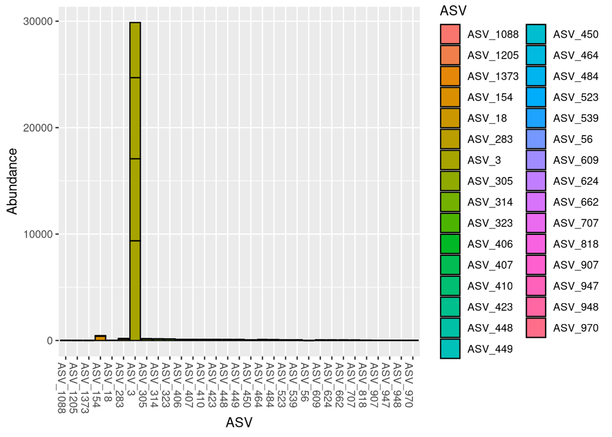

```r
# Vector of control ASVs
control_ASVs <-
  control_physeq %>%
  tax_table() %>%
  data.frame() %>%
  dplyr::select(ASV) %>%
  as.vector()

# Visualize raw abundance values of control ASVs
control_physeq %>%
  plot_bar(., "ASV", fill = "ASV")
```

```r
################# Check the control ASVs in the samples
# Make a new phyloseq object with only the control ASVs and all samples
control_ASV_physeq <-
  noChlorosMitos_physeq %>%
  subset_taxa(., ASV %in% control_ASVs$ASV)

# Inspect it
control_ASV_physeq
```

```
## phyloseq-class experiment-level object
## otu_table()   OTU Table:         [ 31 taxa and 95 samples ]
## sample_data() Sample Data:       [ 95 samples by 47 sample variables ]
## tax_table()   Taxonomy Table:    [ 31 taxa by 9 taxonomic ranks ]
```

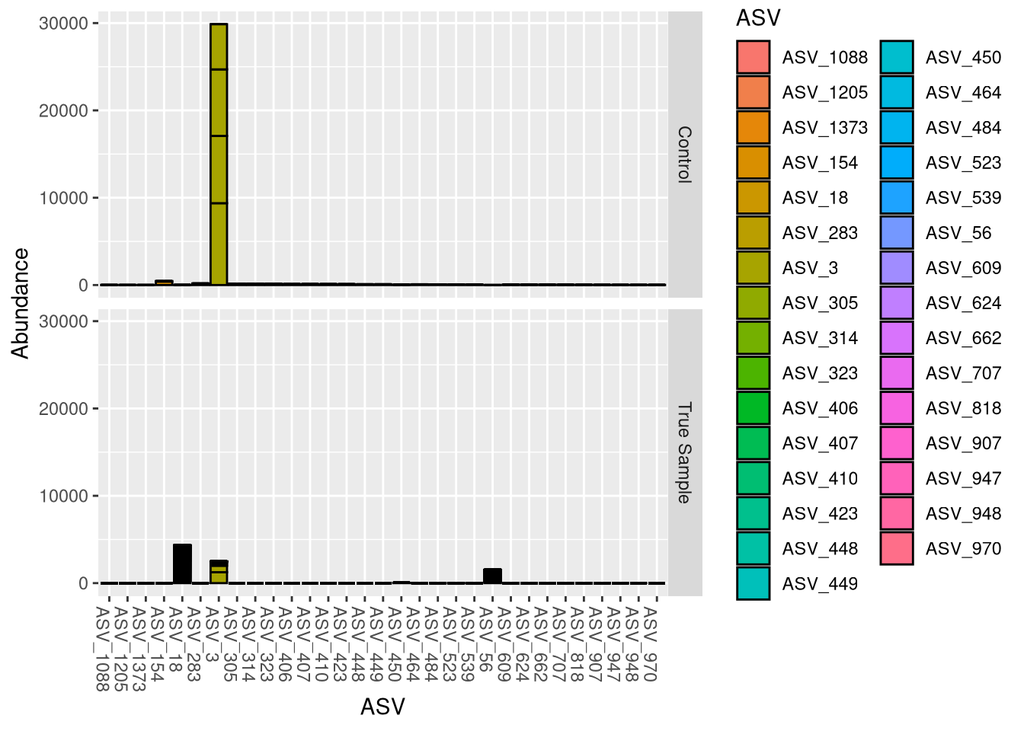

```r
# Let's take a look at the abundances
control_ASV_physeq %>%
  plot_bar(., "ASV", fill = "ASV", facet_grid = Sample_or_Control~.)
```

```r
#Check tax of ASV 3
#control_ASV_physeq %>%
#  tax_table() %>%
#  data.frame() %>%
#  View()

# Would only like to keep ASV 18 and ASV 56. Everything else is trash.
control_ASVs_toREMOVE <- dplyr::setdiff(control_ASVs$ASV,
                                        c("ASV_18", "ASV_56"))

# Intution check
control_ASVs_toREMOVE
```

```
##  [1] "ASV_3"    "ASV_154"  "ASV_283"  "ASV_305"  "ASV_314"  "ASV_323"
##  [7] "ASV_406"  "ASV_407"  "ASV_410"  "ASV_423"  "ASV_448"  "ASV_449"
## [13] "ASV_450"  "ASV_464"  "ASV_484"  "ASV_523"  "ASV_539"  "ASV_609"
## [19] "ASV_624"  "ASV_662"  "ASV_707"  "ASV_818"  "ASV_907"  "ASV_947"
## [25] "ASV_948"  "ASV_970"  "ASV_1088" "ASV_1205" "ASV_1373"
```

```r
length(control_ASVs_toREMOVE)
```

```
## [1] 29
```

```r
### Make new phyloseq object
noControlsChlorosMitos_physeq <-
  noChlorosMitos_physeq %>%
  # Actually remove the control ASVs except 18 and 56
  subset_taxa(., !(ASV %in% control_ASVs_toREMOVE)) %>%
  # Remove control samples
  subset_samples(., !(names %in% control_samples))

# Inspect no controls object
noControlsChlorosMitos_physeq
```

```
## phyloseq-class experiment-level object
## otu_table()   OTU Table:         [ 2685 taxa and 91 samples ]
## sample_data() Sample Data:       [ 91 samples by 47 sample variables ]
## tax_table()   Taxonomy Table:    [ 2685 taxa by 9 taxonomic ranks ]
```

```r
# After filtering, how many ASVs were removed?
total_ASVs_rm <- ntaxa(raw_physeq) - ntaxa(noControlsChlorosMitos_physeq)
```

# Evaluate Accuracy in the Mock Community

- Make a mock phyloseq object
- Load in the standard fasta sequences of the mock community
- Test for differences between the two

```r
# Make mock phyloseq object
mock_physeq <-
  noControlsChlorosMitos_physeq %>%
  subset_samples(., names == "MockZymoPos") %>%
  # Mock zymo community is our positive control
  prune_taxa(taxa_sums(.) > 0, .)

# Inspect it
mock_physeq
```

```
## phyloseq-class experiment-level object
## otu_table()   OTU Table:         [ 8 taxa and 1 samples ]
## sample_data() Sample Data:       [ 1 samples by 47 sample variables ]
## tax_table()   Taxonomy Table:    [ 8 taxa by 9 taxonomic ranks ]
```

```r
tax_table(mock_physeq)
```

```
## Taxonomy Table:     [8 taxa by 9 taxonomic ranks]:
##         Kingdom    Phylum           Class                 Order
## ASV_106 "Bacteria" "Proteobacteria" "Gammaproteobacteria" "Enterobacterales"
## ASV_120 "Bacteria" "Firmicutes"     "Bacilli"             "Staphylococcales"
## ASV_136 "Bacteria" "Proteobacteria" "Gammaproteobacteria" "Enterobacterales"
## ASV_139 "Bacteria" "Firmicutes"     "Bacilli"             "Lactobacillales"
## ASV_151 "Bacteria" "Firmicutes"     "Bacilli"             "Bacillales"
## ASV_180 "Bacteria" "Firmicutes"     "Bacilli"             "Lactobacillales"
## ASV_193 "Bacteria" "Firmicutes"     "Bacilli"             "Lactobacillales"
## ASV_230 "Bacteria" "Proteobacteria" "Gammaproteobacteria" "Pseudomonadales"
##         Family               Genus                  Species ASV
## ASV_106 "Enterobacteriaceae" "Salmonella"           NA      "ASV_106"
## ASV_120 "Staphylococcaceae"  "Staphylococcus"       NA      "ASV_120"
## ASV_136 "Enterobacteriaceae" "Escherichia-Shigella" NA      "ASV_136"
## ASV_139 "Listeriaceae"       "Listeria"             NA      "ASV_139"
## ASV_151 "Bacillaceae"        "Bacillus"             NA      "ASV_151"
## ASV_180 "Lactobacillaceae"   "Limosilactobacillus"  NA      "ASV_180"
## ASV_193 "Enterococcaceae"    "Enterococcus"         NA      "ASV_193"
## ASV_230 "Pseudomonadaceae"   "Pseudomonas"          NA      "ASV_230"
##         ASVseq
## ASV_106 "CGGAGGGTGCAAGCGTTAATCGGAATTACTGGGCGTAAAGCGCACGCAGGCGGTCTGTCA…"
## ASV_120 "CGTAGGTGGCAAGCGTTATCCGGAATTATTGGGCGTAAAGCGCGCGTAGGCGGTTTTTTA…"
## ASV_136 "CGGAGGGTGCAAGCGTTAATCGGAATTACTGGGCGTAAAGCGCACGCAGGCGGTTTGTTA…"
## ASV_139 "CGTAGGTGGCAAGCGTTGTCCGGATTTATTGGGCGTAAAGCGCGCGCAGGCGGTCTTTTA…"
## ASV_151 "CGTAGGTGGCAAGCGTTGTCCGGAATTATTGGGCGTAAAGGGCTCGCAGGCGGTTCCTTA…"
## ASV_180 "CGTAGGTGGCAAGCGTTATCCGGATTTATTGGGCGTAAAGAGAGTGCAGGCGGTTTTCTA…"
## ASV_193 "CGTAGGTGGCAAGCGTTGTCCGGATTTATTGGGCGTAAAGCGAGCGCAGGCGGTTTCTTA…"
## ASV_230 "CGAAGGGTGCAAGCGTTAATCGGAATTACTGGGCGTAAAGCGCGCGTAGGTGGTTCAGCA…"
```

```r
# Write us a message summarizing this
cat("DADA2 inferred", ntaxa(mock_physeq), "ASVs present in the mock community.")
```

```
## DADA2 inferred 8 ASVs present in the mock community.
```

```r
######## Load in mock reference sequences from Zymo
mock_ref <- getSequences("data/02_PreProcessing/mock_amplicons.fasta")
names(mock_ref)
```

```
## [1] "Staphylococcus_aureus_16S_1"   "Salmonella_enterica_16S_1"
## [3] "Salmonella_enterica_16S_2"     "Pseudomonas_aeruginosa_16S_1"
## [5] "Listeria_monocytogenes_16S_1"  "Lactobacillus_fermentum_16S_1"
## [7] "Escherichia_coli_16S_1"        "Enterococcus_faecalis_16S_1"
## [9] "Bacillus_subtilis_16S_1"
```

```r
### Pull out seqs from Sequenced Mock community
mock_seqs <-
   mock_physeq %>%
     tax_table() %>%
     data.frame %>%
     dplyr::select(ASV, ASVseq)
# Inspect
head(mock_seqs)
```

```
##             ASV
## ASV_106 ASV_106
## ASV_120 ASV_120
## ASV_136 ASV_136
## ASV_139 ASV_139
## ASV_151 ASV_151
## ASV_180 ASV_180
##                                                                                                                                                                                                                                                            ASVseq
## ASV_106 CGGAGGGTGCAAGCGTTAATCGGAATTACTGGGCGTAAAGCGCACGCAGGCGGTCTGTCA…
## ASV_120 CGTAGGTGGCAAGCGTTATCCGGAATTATTGGGCGTAAAGCGCGCGTAGGCGGTTTTTTA…
## ASV_136 CGGAGGGTGCAAGCGTTAATCGGAATTACTGGGCGTAAAGCGCACGCAGGCGGTTTGTTA…
## ASV_139 CGTAGGTGGCAAGCGTTGTCCGGATTTATTGGGCGTAAAGCGCGCGCAGGCGGTCTTTTA…
## ASV_151 CGTAGGTGGCAAGCGTTGTCCGGAATTATTGGGCGTAAAGGGCTCGCAGGCGGTTCCTTA…
## ASV_180 CGTAGGTGGCAAGCGTTATCCGGATTTATTGGGCGTAAAGAGAGTGCAGGCGGTTTTCTA…
```

```r
# Which ASVs match the reference?
matched_asvs <-
  mock_seqs %>%
  rowwise() %>%
  # Check each ASV if they match, will equal TRUE, if not = FALSE
  mutate(Match = any(grepl(ASVseq, mock_ref))) %>%
  # Create a vector of names that matched
  pull(ASV)

cat(length(matched_asvs), "ASVs were exact matched to the expected reference sequence." )
```

```
## 8 ASVs were exact matched to the expected reference sequence.
```

```r
# Evaluate the sequence depth by looking at mock_physeq
mock_SeqDepth <-
  mock_physeq %>%
  otu_table() %>%
  data.frame() %>%
  colSums()

# Evaluate which ASVs do not match
# What are their abundances
# This helps provide error rate

# Who is in the sequenced mock community?
mock_physeq %>%
  tax_table() %>%
  data.frame() %>%
  dplyr::select(Genus, Species)
```

```
##                        Genus Species
## ASV_106           Salmonella    <NA>
## ASV_120       Staphylococcus    <NA>
## ASV_136 Escherichia-Shigella    <NA>
## ASV_139             Listeria    <NA>
## ASV_151             Bacillus    <NA>
## ASV_180  Limosilactobacillus    <NA>
## ASV_193         Enterococcus    <NA>
## ASV_230          Pseudomonas    <NA>
```

```r
names(mock_ref)
```

```
## [1] "Staphylococcus_aureus_16S_1"   "Salmonella_enterica_16S_1"
## [3] "Salmonella_enterica_16S_2"     "Pseudomonas_aeruginosa_16S_1"
## [5] "Listeria_monocytogenes_16S_1"  "Lactobacillus_fermentum_16S_1"
## [7] "Escherichia_coli_16S_1"        "Enterococcus_faecalis_16S_1"
## [9] "Bacillus_subtilis_16S_1"
```

```r
# Curious: What are the mock counts in the actual samples
noControlsChlorosMitos_physeq %>%
  subset_taxa(., ASV %in% matched_asvs) %>%
  otu_table() %>%
  t()
```

```
## OTU Table:          [8 taxa and 91 samples]
##                      taxa are columns
##                   ASV_106 ASV_120 ASV_136 ASV_139 ASV_151 ASV_180 ASV_193
## 20210602-MA-ABB1F       0       0       0       0       0       0       0
## 20210602-MA-ABB1P       0       0       0       0       0       0       0
## 20210602-MA-ABB1W       0       0       0       0       0       0       0
## 20210602-MA-ABS1F       0       0       0       0       0       0       0
## 20210602-MA-ABS1P       0       0       0       0       0       0       0
## 20210602-MA-ABS1W       0       0       0       0       0       0       0
## 20210602-MA-CEB1F       0       0       0       0       0       0       0
## 20210602-MA-CEB1P       0       0       0       0       0       0       0
## 20210602-MA-CEB1W       0       0       0       0       0       0       0
## 20210602-MA-CES1F       0       0       0       0       0       0       0
## 20210602-MA-CES1P       0       0       0       0       0       0       0
## 20210602-MA-CES1W       0       0       0       0       0       0       0
## 20210602-MA-CWB1F       0       0       0       0       0       0       0
## 20210602-MA-CWB1P       0       0       0       0       0       0       0
## 20210602-MA-CWB1W       0       0       0       0       0       0       0
## 20210602-MA-CWS1F       0       0       0       0       0       0       0
## 20210602-MA-CWS1P       0       0       0       0       0       0       0
## 20210602-MA-CWS1W       0       0       0       0       0       0       0
## 20210602-MA-MBB1F       0       0       0       0       0       0       0
## 20210602-MA-MBB1P       0       0       0       0       0       0       0
## 20210602-MA-MBB1W       0       0       0       0       0       0       0
## 20210602-MA-MBS1F       0       0       0       0       0       0       0
## 20210602-MA-MBS1P       0       0       0       0       0       0       0
## 20210602-MA-MBS1W       0       0       0       0       0       0       0
## 20210602-MA-SCB1F       0       0       0       0       0       0       0
## 20210602-MA-SCB1P       0       0       0       0       0       0       0
## 20210602-MA-SCB1W       0       0       0       0       0       0       0
## 20210602-MA-SCS1F       0       0       0       0       0       0       0
## 20210602-MA-SCS1P       0       0       0       0       0       0       0
## 20210602-MA-SCS1W       0       0       0       0       0       0       0
## 20210615-MA-ABB2F       0       0       0       0       0       0       0
## 20210615-MA-ABB2P       0       0       0       0       0       0       0
## 20210615-MA-ABB2W       0       0       0       0       0       0       0
## 20210615-MA-ABS1F       0       0       0       0       0       0       0
## 20210615-MA-ABS1P       0       0       0       0       0       0       0
## 20210615-MA-ABS1W       0       0       0       0       0       0       0
## 20210615-MA-CEB1F       0       0       0       0       0       0       0
```

[output cut: 131 more lines]

```
## 20211005-MA-CWS1P       0
## 20211005-MA-CWS1W       0
## 20211005-MA-MBB1F       0
## 20211005-MA-MBB1P       0
## 20211005-MA-MBB1W       0
## 20211005-MA-MBS1F       0
## 20211005-MA-MBS1P       0
## 20211005-MA-MBS1W       0
## 20211005-MA-SCB1F       0
## 20211005-MA-SCB1P       0
## 20211005-MA-SCB1W       0
## 20211005-MA-SCS2F       0
## 20211005-MA-SCS2P       0
## 20211005-MA-SCS2W       0
## MockZymoPos           274
```

What can we conclude about the mock community? That all 8 ASVs in the mock exactly match 8 of 9 in the reference file.

```r
# Make a new phyloseq object without mock and its asvs
noControlsMockChlorosMitos_physeq <-
  noControlsChlorosMitos_physeq %>%
  # remove the mock community
  subset_samples(., names != "MockZymoPos") %>%
  # remove the ASVs from the mock
  subset_taxa(., !(ASV %in% matched_asvs))

# Intuition check
num_ASVs_mock <- ntaxa(noControlsChlorosMitos_physeq) -
  ntaxa(noControlsMockChlorosMitos_physeq)

stopifnot(num_ASVs_mock == 8)
```

# Evaluate the Sequencing Depth

```r
# The current data object
noControlsMockChlorosMitos_physeq
```

```
## phyloseq-class experiment-level object
## otu_table()   OTU Table:         [ 2677 taxa and 90 samples ]
## sample_data() Sample Data:       [ 90 samples by 47 sample variables ]
## tax_table()   Taxonomy Table:    [ 2677 taxa by 9 taxonomic ranks ]
```

```r
# What is the library size/sequencing depth for each sample?
seqSums_df <-
  noControlsMockChlorosMitos_physeq %>%
  otu_table() %>%
  # Sum each sample column
  colSums() %>%
  data.frame() %>%
  rownames_to_column(var = "names") %>%
  left_join(., metadata_track_reads_df, by = "names")

# Rename second column
colnames(seqSums_df)[2] <- "TotalSeqs"

# check
dim(seqSums_df)
```

```
## [1] 90 48
```

```r
head(seqSums_df)
```

```
##               names TotalSeqs year day project     station depth replicate
## 1 20210602-MA-ABB1F      4029 2021  02      MA Aransas Bay   2.5         1
## 2 20210602-MA-ABB1P      3086 2021  02      MA Aransas Bay   2.5         1
## 3 20210602-MA-ABB1W      5725 2021  02      MA Aransas Bay   2.5         1
## 4 20210602-MA-ABS1F      3824 2021  02      MA Aransas Bay   0.0         1
## 5 20210602-MA-ABS1P      3743 2021  02      MA Aransas Bay   0.0         1
## 6 20210602-MA-ABS1W      4750 2021  02      MA Aransas Bay   0.0         1
##   fraction   date month vol_filtered_mL DNA_conc1a_nguL total_uL_DNA tot_ng
## 1     Free 6/2/21  June             360           25.90        44.61   1207
## 2 Particle 6/2/21  June             360            2.91        34.00    105
## 3    Whole 6/2/21  June             360           65.30        43.36   2962
## 4     Free 6/2/21  June             300           39.70        44.94   1864
## 5 Particle 6/2/21  June             300           10.40        42.54    463
## 6    Whole 6/2/21  June             300           47.40        45.11   2233
##   DNA_conc1b_nguL  DNA_conc2_nguL tot_filtration_time collection_time
```

[output cut: 41 more lines]

```r
# Show the depth of samples
seqSums_df %>%
  dplyr::select(names, TotalSeqs) %>%
  arrange(TotalSeqs) %>%
  head()
```

```
##               names TotalSeqs
## 1 20210615-MA-SCB2F         0
## 2 20210615-MA-ABB2F      1836
## 3 20210602-MA-CWS1P      2194
## 4 20210602-MA-SCB1P      2256
## 5 20211005-MA-CWS1P      2619
## 6 20210602-MA-MBB1P      2655
```

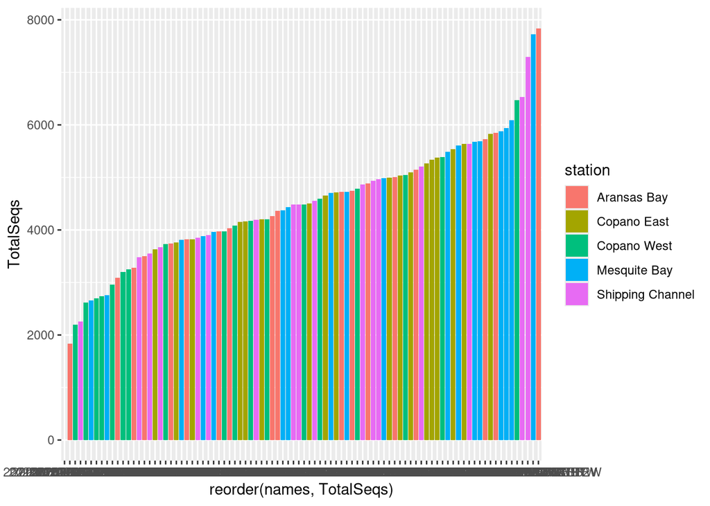

```r
# plot it!
seqSums_df %>%
  ggplot(aes(x=reorder(names, TotalSeqs), y = TotalSeqs,
             fill = station)) +
  geom_bar(stat = "identity")
```

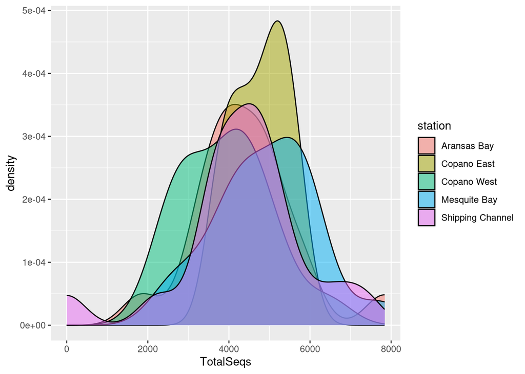

```r
# Density plot
seqSums_df %>%
  ggplot(aes(TotalSeqs, fill = station)) +
  geom_density(alpha = 0.5)
```

# Remove samples with few reads

```r
# What's the min seq depth?
min(sample_sums(noControlsMockChlorosMitos_physeq))
```

```
## [1] 0
```

```r
# Remove 20210615-MA-SCB2F
raw_preprocessed_physeq <-
  noControlsMockChlorosMitos_physeq %>%
  subset_samples(., names != "20210615-MA-SCB2F")

#What's the new min seq depth?
min(sample_sums(raw_preprocessed_physeq))
```

```
## [1] 1836
```

# Save Preprocessed Phyloseq Object

```r
save(raw_preprocessed_physeq,
     file = "data/02_PreProcessing/raw_preprocessed_physeq.RData")
```